# Solar Panel Degradation Analysis

Harry White, Doug Duril

March 23, 2017

### Introduction, Motivation

The market for solar energy is growing rapidly, as more businesses and homeowners install solar generation systems. While the basic technology for photovoltaic (PV) panels, inverters, and other hardware is well-defined, there continue to be questions about the long-term performance. The majority of the solar infrastructure has been installed in the last 10 yrs, not long enough to get significant data on long-term failure modes such as decrease in PV power output over time. The prediction of power degradation over time is a significant business issue for the PV industry, as it will have a strong effect on both the end customers and the PV manufacturers. Faster rates of PV degradation will result in unhappy customers and increased costs to the PV manufacturers (warranty claims, etc).

To fill the knowledge gap and better understand technical and business risks, manufacturers have done accelerated-life testing on PV components and panels at elevated stress conditions (high temperature, humidity, UV exposure). Some information is known about the activation energies for the Physics of Failure (PoF), and this can be used to estimate degradation over time.

Analysis of PV degradation is a data-intensive activity and a great opportunity to apply the strengths of R software. For our project, we have hypothesized that we own a solar company that is deploying PV panels nationwide. Our company is based in Minneapolis, and we have some field experience for panels deployed in that location, but we want to estimate power degradation that will occur in hotter and/or more humid environments (southern states, for example).

### Dataset Information

A literature search shows that the primary factors causing PV degradation include temperature, humidity, and UV exposure. For our R project we defined an expression which includes temperature and humidity, and used this to estimate degradation in a set of 50 cities in which our PV panels will be deployed.

$$Degradation = (1-EXP(A*[Years]))*(EXP(H*((1/[Humid1])-(1/[Humid2]))))* \\ (EXP(0.6*((k/(273.15+[Temp1]))-(k/(273.15+[Temp2])))))$$

where

A = Baseline degradation due to time only. In this project it was set to -0.004.  
H = Acceleration factor due to humidity. In this project it was set to 0.3.  
B = Acceleration factor due to temperature. In this project it was set to 0.6.  
k = Boltzmann’s constant, =11605 in the units used here.  
Temp1, Humid1 = Baseline temperature and humidity in Minneapolis  
Temp2, Humid2 = Temperature and humidity of the city

Using this approach, we can find out the relative degradation in each city compared to Minneapolis (home site of the company, and where some field data is available).

Information on temperature and humidity as a function of location was acquired and built into the City Weather dataset.

The City Weather dataset was collected from [Current Results](http://www.currentresults.com/) and contains State-wide temperature and humidity averages. The city data is based on weather station readings collected during the years 1971 - 2000 and provided by the [NOAA National Climatic Data Center](https://www.ncdc.noaa.gov/) of the United States.

For the purposes of this analysis, the team chose to focus on the Top 50 US Cities to examine the effects of high heat and humidity on materials used in the manufacture of solarpanels.

**Average Yearly Temperature and Humidity for Major US Cities** *(cities.json)*

- **city**: City
- **state**: State
- **region**: US Census Region (Northeast, Midwest, South, and West)
- **division**: US Census Division (2-3 per US Census Region)
- **avg_temp_f**: Average Yearly Temperature Fahrenheit
- **avg_temp_c**: Average Yearly Temperature Celsius
- **avg_humidity**: Average Yearly Humidity
- **latitude**: Latitude
- **longitude**: Longitude

**Solar Degradation Ongoing** *(solar-degradation-ongoing.csv)*

- **city**: City (foreign key to cities.json:city)
- **[X0-X50]**: Calculated values from year 0 to year 50

### Packages

```r
## Loading required packages
library(dplyr)
library(ggplot2)
library(jsonlite)
library(maps)
```

### Data Loading

```r
## read in json file
cities_file <- "c:/development/cities.json" # assuming file is on this path
cities_str <- paste(readLines(cities_file), collapse = "")
cities_df <- fromJSON(cities_str)
dim(cities_df)
```

```
## [1] 50  9
```

```r
## output sample city data.frame
(select(head(cities_df), city, state, avg_temp_f, avg_temp_c, avg_humidity))
```

```
##         city         state avg_temp_f avg_temp_c avg_humidity
## 1    Atlanta       Georgia       62.5       17.0           68
## 2     Austin         Texas       69.5       21.0           67
## 3  Baltimore      Maryland       55.0       12.5           66
## 4 Birmingham       Alabama       63.5       17.5           70
## 5     Boston Massachusetts       51.5       11.0           67
## 6    Buffalo      New York       48.0        9.5           72
```

```r
## read in Solar Degradation data csv file
dg_df <- read.csv("c:/development/solar-degradation-ongoing.csv")
dim(dg_df)
```

```
## [1] 50 52
```

```r
## output sample degradation data.frame
(select(head(dg_df), city, X0, X1, X2, X4, X5, X6, X7, X8, X9, X10))
```

```
##          city    X0    X1    X2    X4    X5    X6    X7    X8    X9   X10
## 1 Minneapolis 0.00% 0.40% 0.80% 1.59% 1.98% 2.37% 2.76% 3.15% 3.54% 3.92%
## 2   Rochester 0.00% 0.45% 0.90% 1.79% 2.23% 2.67% 3.11% 3.54% 3.98% 4.41%
## 3   Milwaukee 0.00% 0.45% 0.89% 1.78% 2.22% 2.65% 3.09% 3.52% 3.96% 4.39%
## 4     Buffalo 0.00% 0.47% 0.93% 1.86% 2.31% 2.77% 3.23% 3.68% 4.13% 4.58%
## 5      Denver 0.00% 0.42% 0.83% 1.65% 2.06% 2.47% 2.87% 3.28% 3.68% 4.08%
## 6     Chicago 0.00% 0.48% 0.96% 1.91% 2.39% 2.86% 3.33% 3.80% 4.27% 4.73%
```

```r
## merge data sets
merged_df <- merge(cities_df, dg_df)
(select(head(merged_df), city, avg_temp_c, avg_humidity, X0, X1, X2, X4, X5))
```

```
##         city avg_temp_c avg_humidity    X0    X1    X2    X4    X5
## 1    Atlanta       17.0           68 0.00% 0.86% 1.72% 3.42% 4.27%
## 2     Austin       21.0           67 0.00% 1.18% 2.37% 4.71% 5.88%
## 3  Baltimore       12.5           66 0.00% 0.58% 1.16% 2.31% 2.89%
## 4 Birmingham       17.5           70 0.00% 0.91% 1.81% 3.61% 4.51%
## 5     Boston       11.0           67 0.00% 0.52% 1.03% 2.05% 2.56%
## 6    Buffalo        9.5           72 0.00% 0.47% 0.93% 1.86% 2.31%
```

```r
## top five hottest cities
(top_five_hottest <- select(head(arrange(merged_df,desc(avg_temp_c)), n = 5), city, avg_temp_c))
```

```
##      city avg_temp_c
## 1   Miami       25.0
## 2 Phoenix       24.0
## 3   Tampa       23.0
## 4 Orlando       22.5
## 5 Houston       21.5
```

```r
## top five coolest cities
(top_five_coolest <- select(tail(arrange(merged_df,desc(avg_temp_c)), n = 5), city, avg_temp_c))
```

```
##           city avg_temp_c
## 46     Detroit       10.0
## 47     Buffalo        9.5
## 48   Milwaukee        9.0
## 49   Rochester        9.0
## 50 Minneapolis        8.0
```

```r
## top five high humidity cities
(top_five_high_humidity <- select(head(arrange(merged_df,desc(avg_humidity)), n = 5), city, avg_humidity))
```

```
##            city avg_humidity
## 1  Jacksonville           76
## 2   New Orleans           76
## 3       Houston           75
## 4       Orlando           74
## 5 San Francisco           74
```

```r
## top five lowest humidity cities
(top_five_low_humidity <- select(tail(arrange(merged_df,desc(avg_humidity)), n = 5), city, avg_humidity))
```

```
##              city avg_humidity
## 46       New York           63
## 47 Salt Lake City           55
## 48         Denver           52
## 49        Phoenix           37
## 50      Las Vegas           30
```

```r
## output single test row
sample_row <-merged_df[8,]
(select(head(sample_row), city, avg_temp_c, avg_humidity, X0, X1, X2, X4, X5))
```

```
##      city avg_temp_c avg_humidity    X0    X1    X2    X4    X5
## 8 Chicago         10           70 0.00% 0.48% 0.96% 1.91% 2.39%
```

```r
tr_df <- read.csv("c:/development/solar-degradation-ongoing-transpose.csv")
dim(tr_df)
```

```
## [1] 51 51
```

```r
colnames(tr_df)
```

```
##  [1] "Year"           "Minneapolis"    "Rochester"      "Milwaukee"
##  [5] "Buffalo"        "Denver"         "Chicago"        "Hartford"
##  [9] "Detroit"        "Pittsburgh"     "Cleveland"      "Boston"
## [13] "Providence"     "Salt.Lake.City" "Seattle"        "Indianapolis"
## [17] "Columbus"       "Portland"       "Cincinnati"     "New.York"
## [21] "Baltimore"      "Philadelphia"   "St..Louis"      "Kansas.City"
## [25] "San.Francisco"  "Washington"     "Louisville"     "Richmond"
## [29] "Nashville"      "Virginia.Beach" "Charlotte"      "San.Jose"
## [33] "Sacramento"     "Raleigh"        "Oklahoma.City"  "Atlanta"
## [37] "Memphis"        "Birmingham"     "San.Diego"      "Los.Angeles"
## [41] "Dallas"         "Jacksonville"   "San.Antonio"    "New.Orleans"
## [45] "Las.Vegas"      "Austin"         "Houston"        "Orlando"
## [49] "Tampa"          "Phoenix"        "Miami"
```

```r
tr_df[-1] <- data.frame(apply(tr_df[-1], 2, function(x) as.numeric(sub("%","",as.character(x)))))
```

### Exploratory

Data was first analyzed in Excel. In our project, the equation to model the degradation was used to build a table in Excel which was then copied into R.

Additional data was acquired through online sources: [Current Results](http://www.currentresults.com/) and [NOAA National Climatic Data Center](https://www.ncdc.noaa.gov/)

```r
## confirm data frame
class(cities_df)
```

```
## [1] "data.frame"
```

```r
## names
names(cities_df)
```

```
## [1] "city"         "state"        "region"       "division"
## [5] "avg_temp_f"   "avg_temp_c"   "avg_humidity" "latitude"
## [9] "longitude"
```

```r
## top rows
head(cities_df)
```

```
##         city         state    region           division avg_temp_f
## 1    Atlanta       Georgia     South     South Atlantic       62.5
## 2     Austin         Texas     South West South Central       69.5
## 3  Baltimore      Maryland     South     South Atlantic       55.0
## 4 Birmingham       Alabama     South East South Central       63.5
## 5     Boston Massachusetts Northeast        New England       51.5
## 6    Buffalo      New York Northeast    Middle Atlantic       48.0
##   avg_temp_c avg_humidity latitude longitude
## 1       17.0           68 33.74900 -84.38798
## 2       21.0           67 30.26715 -97.74306
## 3       12.5           66 39.29038 -76.61219
## 4       17.5           70 33.52066 -86.80249
## 5       11.0           67 42.36008 -71.05888
## 6        9.5           72 42.88645 -78.87837
```

```r
## summary
summary(cities_df)
```

```
##      city              state              region
##  Length:50          Length:50          Length:50
##  Class :character   Class :character   Class :character
##  Mode  :character   Mode  :character   Mode  :character
##
##
##
##    division           avg_temp_f      avg_temp_c     avg_humidity
##  Length:50          Min.   :46.00   Min.   : 8.00   Min.   :30.00
##  Class :character   1st Qu.:53.12   1st Qu.:11.62   1st Qu.:67.00
##  Mode  :character   Median :58.50   Median :14.50   Median :69.50
##                     Mean   :59.14   Mean   :15.06   Mean   :67.60
##                     3rd Qu.:63.88   3rd Qu.:17.50   3rd Qu.:71.75
##                     Max.   :77.00   Max.   :25.00   Max.   :76.00
##     latitude       longitude
##  Min.   :25.76   Min.   :-122.68
##  1st Qu.:34.23   1st Qu.: -97.69
##  Median :38.42   Median : -86.79
##  Mean   :37.46   Mean   : -91.52
##  3rd Qu.:40.75   3rd Qu.: -80.04
##  Max.   :47.61   Max.   : -71.06
```

```r
## average temperature celsius
min(cities_df$avg_temp_c)
```

```
## [1] 8
```

```r
max(cities_df$avg_temp_c)
```

```
## [1] 25
```

```r
fivenum(cities_df$avg_temp_c)
```

```
## [1]  8.0 11.5 14.5 17.5 25.0
```

```r
## average humidity
min(cities_df$avg_humidity)
```

```
## [1] 30
```

```r
max(cities_df$avg_humidity)
```

```
## [1] 76
```

```r
fivenum(cities_df$avg_humidity)
```

```
## [1] 30.0 67.0 69.5 72.0 76.0
```

```r
## filter
## filter by region == "West"
df <- filter(cities_df, region == "West")
df <- select(df, region, division, state, city, avg_temp_f, avg_temp_c)
df <- arrange(df, region, division, state, city)
df
```

```
##    region division      state           city avg_temp_f avg_temp_c
## 1    West Mountain    Arizona        Phoenix       75.0       24.0
## 2    West Mountain   Colorado         Denver       50.0       10.0
## 3    West Mountain     Nevada      Las Vegas       69.5       21.0
## 4    West Mountain       Utah Salt Lake City       53.0       11.5
## 5    West  Pacific California    Los Angeles       65.5       18.5
## 6    West  Pacific California     Sacramento       61.0       16.0
## 7    West  Pacific California      San Diego       64.0       17.5
## 8    West  Pacific California  San Francisco       57.5       14.0
## 9    West  Pacific California       San Jose       60.5       16.0
## 10   West  Pacific     Oregon       Portland       54.0       12.0
## 11   West  Pacific Washington        Seattle       53.5       12.0
```

```r
## filter, Select, Arrange by division == "Pacific""
df <- filter(cities_df, division == "Pacific")
df <- select(df, region, division, state, city, avg_temp_f, avg_temp_c)
df <- arrange(df, region, division, state, city)
df
```

```
##   region division      state          city avg_temp_f avg_temp_c
## 1   West  Pacific California   Los Angeles       65.5       18.5
## 2   West  Pacific California    Sacramento       61.0       16.0
## 3   West  Pacific California     San Diego       64.0       17.5
## 4   West  Pacific California San Francisco       57.5       14.0
## 5   West  Pacific California      San Jose       60.5       16.0
## 6   West  Pacific     Oregon      Portland       54.0       12.0
## 7   West  Pacific Washington       Seattle       53.5       12.0
```

```r
## arrange
## arrange by avg_temp_f desc
df <- select(cities_df, state, city, avg_temp_c, avg_humidity)
df <- arrange(df, desc(avg_temp_c))
df
```

```
##                   state           city avg_temp_c avg_humidity
## 1               Florida          Miami       25.0           73
## 2               Arizona        Phoenix       24.0           37
## 3               Florida          Tampa       23.0           74
## 4               Florida        Orlando       22.5           74
## 5                 Texas        Houston       21.5           75
## 6                 Texas         Austin       21.0           67
## 7                Nevada      Las Vegas       21.0           30
## 8             Louisiana    New Orleans       21.0           76
## 9                 Texas    San Antonio       21.0           67
## 10       North Carolina   Jacksonville       20.0           76
## 11                Texas         Dallas       19.5           65
## 12           California    Los Angeles       18.5           71
## 13              Alabama     Birmingham       17.5           70
## 14            Tennessee        Memphis       17.5           67
```

[output cut: 36 more lines]

```r
## mutate - add column - simple addition, but could use complex formulas
df <- select(cities_df,
                      city,
                      avg_temp_f
)
mutate(df,
       temp_plus_10 = avg_temp_f + 10.0,
       temp_plus_20 = avg_temp_f + 20.0
)
```

```
##              city avg_temp_f temp_plus_10 temp_plus_20
## 1         Atlanta       62.5         72.5         82.5
## 2          Austin       69.5         79.5         89.5
## 3       Baltimore       55.0         65.0         75.0
## 4      Birmingham       63.5         73.5         83.5
## 5          Boston       51.5         61.5         71.5
## 6         Buffalo       48.0         58.0         68.0
## 7       Charlotte       60.0         70.0         80.0
## 8         Chicago       50.0         60.0         70.0
## 9      Cincinnati       54.0         64.0         74.0
## 10      Cleveland       51.5         61.5         71.5
## 11       Columbus       53.5         63.5         73.5
## 12         Dallas       67.0         77.0         87.0
## 13         Denver       50.0         60.0         70.0
## 14        Detroit       50.5         60.5         70.5
```

[output cut: 36 more lines]

```r
## group_by and summarize
summarize(cities_df, mean_temp_c = mean(avg_temp_c, na.rm = TRUE))
```

```
##   mean_temp_c
## 1       15.06
```

### Visualization

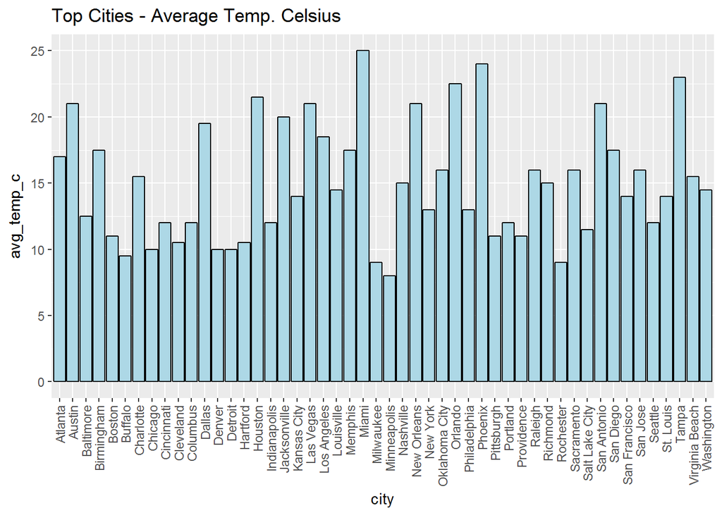

```r
## bar chart - average temp celsius
ggplot(cities_df, aes(x=city, y=avg_temp_c)) +
  geom_bar(stat = "identity", fill = "lightblue", color="black") +
  theme(axis.text.x=element_text(angle=90,hjust=1,vjust=0.5)) + ggtitle("Top Cities - Average Temp. Celsius")
```

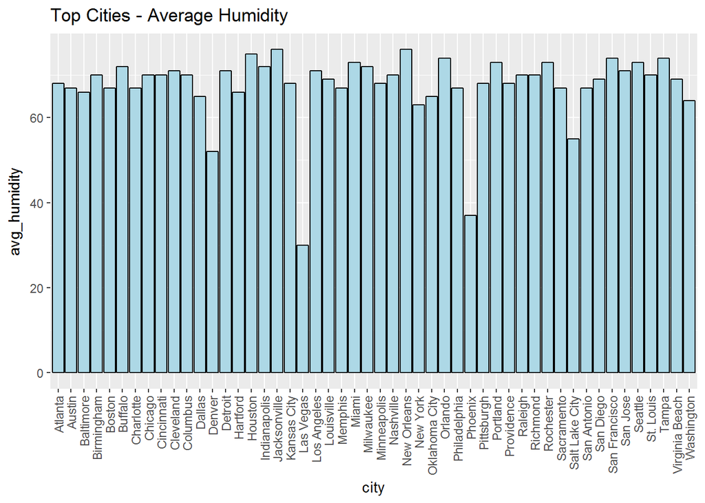

```r
## bar chart - average humidity
ggplot(cities_df, aes(x=city, y=avg_humidity)) +
  geom_bar(stat = "identity", fill = "lightblue", color="black") +
  theme(axis.text.x=element_text(angle=90,hjust=1,vjust=0.5)) + ggtitle("Top Cities - Average Humidity")
```

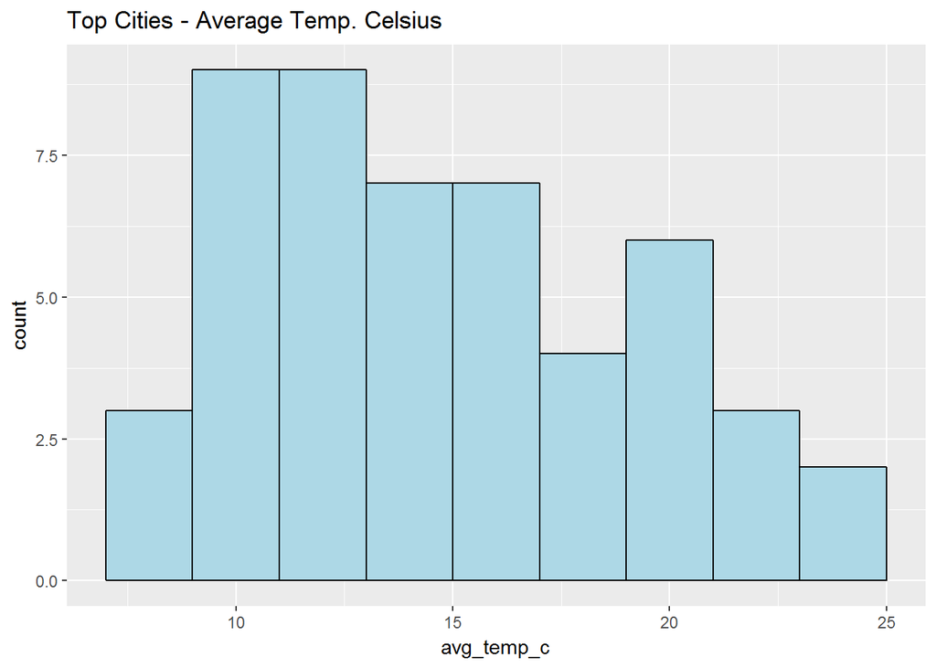

```r
## histogram of avg_temp_c
ggplot(cities_df, aes(avg_temp_c)) +
  geom_histogram(
    binwidth = 2,
    color="black",
    fill="lightblue"
  ) + ggtitle("Top Cities - Average Temp. Celsius")
```

```r
## coolest city - minneapolis
x <- subset(tr_df, select = c(Year ,Minneapolis))
x
```

```
##    Year Minneapolis
## 1  2017        0.00
## 2  2018        0.40
## 3  2019        0.80
## 4  2020        1.19
## 5  2021        1.59
## 6  2022        1.98
## 7  2023        2.37
## 8  2024        2.76
## 9  2025        3.15
## 10 2026        3.54
## 11 2027        3.92
## 12 2028        4.30
## 13 2029        4.69
## 14 2030        5.07
```

[output cut: 37 more lines]

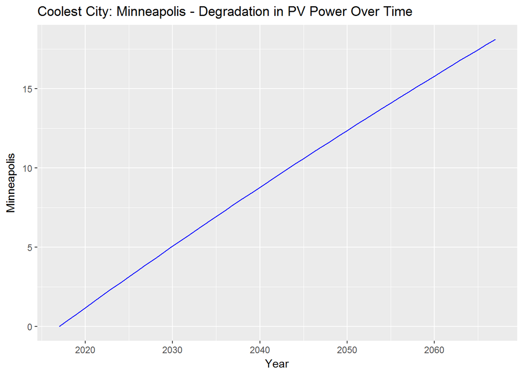

```r
ggplot(data=tr_df, aes(x=Year, y=Minneapolis, group=1)) + geom_line(color="blue") + ggtitle("Coolest City: Minneapolis - Degradation in PV Power Over Time")
```

```r
## warmest city - miami
x <- subset(tr_df, select = c(Year ,Miami))
x
```

```
##    Year Miami
## 1  2017  0.00
## 2  2018  1.69
## 3  2019  3.37
## 4  2020  5.05
## 5  2021  6.72
## 6  2022  8.38
## 7  2023 10.03
## 8  2024 11.68
## 9  2025 13.32
## 10 2026 14.96
## 11 2027 16.59
## 12 2028 18.21
## 13 2029 19.83
## 14 2030 21.44
```

[output cut: 37 more lines]

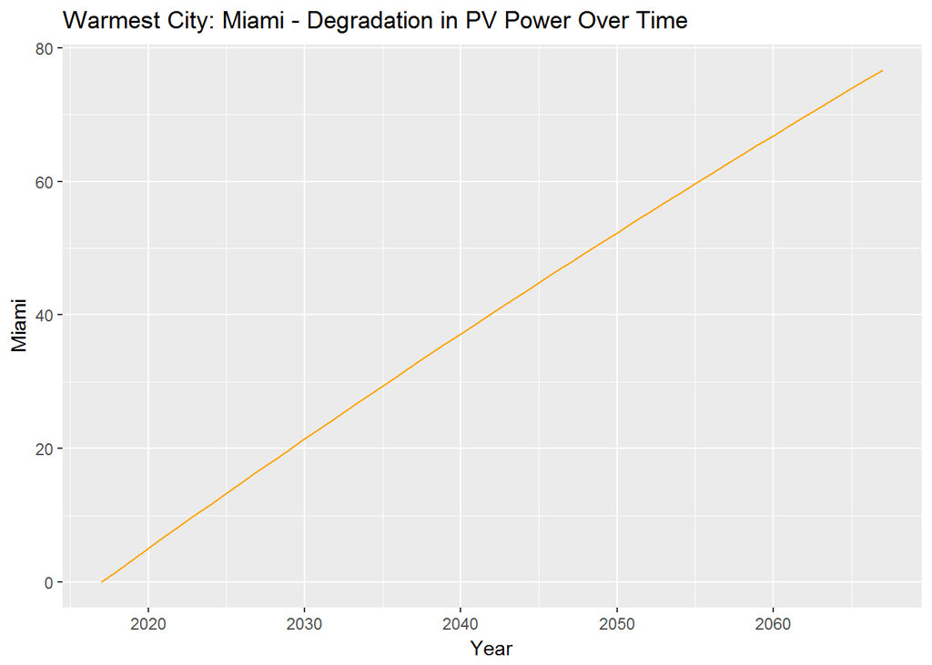

```r
ggplot(data=tr_df, aes(x=Year, y=Miami, group=1)) + geom_line(color="orange") + ggtitle("Warmest City: Miami - Degradation in PV Power Over Time")
```

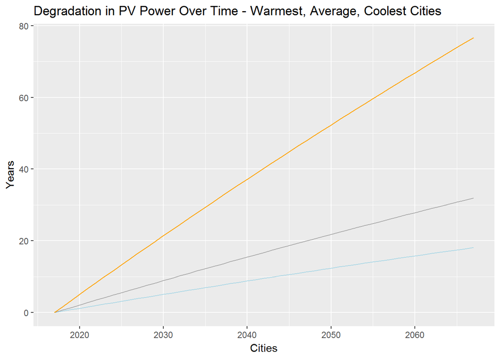

```r
ggplot(tr_df, aes(x = Year)) +
  geom_line(aes(y = Minneapolis), colour="lightblue") +
  geom_line(aes(y = Louisville), colour = "darkgray") +
  geom_line(aes(y = Miami), colour = "orange") +
  ylab(label="Years") +
  xlab("Cities") +
  ggtitle("Degradation in PV Power Over Time - Warmest, Average, Coolest Cities")
```

```r
top_five_hottest <- select(head(arrange(merged_df,desc(avg_temp_c)), n = 5), city, avg_temp_c, X0, X10, X20, X30, X40, X50)
top_five_hottest <- plyr::rename(top_five_hottest, c("X0"="year 0", "X10"="10 yrs", "X20"="20 yrs", "X30"="30 yrs", "X40"="40 yrs", "X50"="50 yrs"))
top_five_hottest
```

```
##      city avg_temp_c year 0 10 yrs 20 yrs 30 yrs 40 yrs 50 yrs
## 1   Miami       25.0  0.00% 16.59% 32.53% 47.84% 62.55% 76.69%
## 2 Phoenix       24.0  0.00% 10.28% 20.16% 29.65% 38.77% 47.53%
## 3   Tampa       23.0  0.00% 14.25% 27.94% 41.09% 53.72% 65.86%
## 4 Orlando       22.5  0.00% 13.69% 26.85% 39.48% 51.63% 63.30%
## 5 Houston       21.5  0.00% 12.71% 24.92% 36.65% 47.92% 58.75%
```

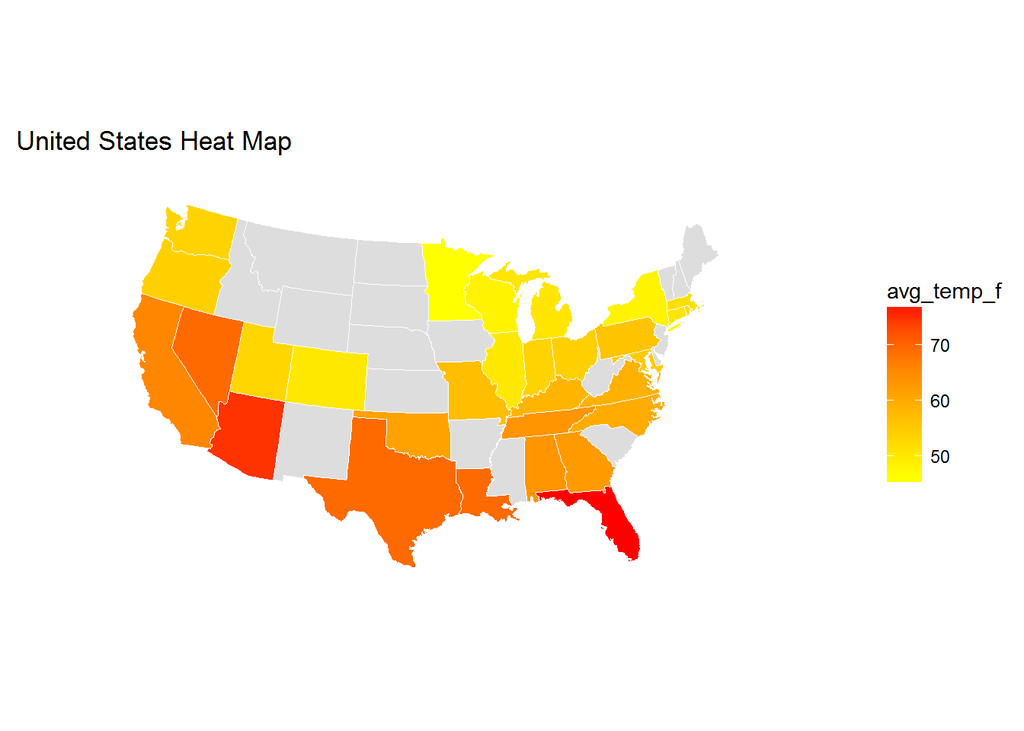

```r
## select fields from data set
cities_df <- select(cities_df, state, city, avg_temp_f, avg_temp_c, avg_humidity)

us <- map_data("state")

arr <- cities_df %>%
  add_rownames("region") %>%
  mutate(region=tolower(state))

gg <- ggplot()
gg <- gg + geom_map(data=us, map=us,
                    aes(x=long, y=lat, map_id=region),
                    fill="#dddddd", color="#ffffff", size=0.15)
gg <- gg + geom_map(data=arr, map=us,
                    aes(fill=avg_temp_f, map_id=region),
                    color="#ffffff", size=0.15)
gg <- gg + scale_fill_continuous(low='yellow', high='red',
                                 guide='colorbar')
gg <- gg + labs(x=NULL, y=NULL)
gg <- gg + coord_map("albers", lat0 = 39, lat1 = 45)
gg <- gg + theme(panel.border = element_blank())
gg <- gg + theme(panel.background = element_blank())
gg <- gg + theme(axis.ticks = element_blank())
gg <- gg + theme(axis.text = element_blank())
gg <- gg + ggtitle("United States Heat Map")
gg
```

### Findings

Tables and charts show that there is significant power degradation in cities with high average temperatures and humidity. This is important information to know for PV companies that are deploying product in these locations. Actions will need to be taken to mitigate the effect of increased failures in these cities. Some options include adjustments to warranty cost planning, availability of spares, etc.

### Conclusions, Future Enhancements

The values of A and H were chosen to be somewhat worst-case assumptions. Going forward, these constants can be adjusted to get a better match between the model and the field data which is accumulated.

If this project were to be continued, a next step would be to have the equation built directly into R and the table generated within R.

Another enhancement would be to add a failure criteria, say a 20% decrease in power, and build a table which shows the estimated number of years of life in each city until the PV panel is considered to have failed.

### References

1. Ndiaye et al, 2013, Degradations of silicon photovoltaic modules: A literature review, Solar Energy 96 (2013) 140-151.
2. Manuel Vazquez and Ignacio Rey-Stolle, Photovoltaic Module Reliability Model Based on Field Degradation Studies, Prog. Photovolt: Res. Appl. 2008; 16:419-433.

### Data Sources

1. [Current Results](http://www.currentresults.com/) - *Weather and science facts. Curated weather data for countries, states and cities.*
2. [NOAA National Climatic Data Center](https://www.ncdc.noaa.gov/) - *Responsible for preserving, monitoring, assessing, and providing public access to the Nation’s climatic data.*